# Sun and Happiness in the United States

Josh Arford

1/11/2021

The following analysis walks through hours of sun by year for the 48 contiguous states in the USA on a geographical level. Following, is a geographical analysis of happiness for the USA. Lastly, a linear regression analysis is performed on the correlation between happiness and hours of sun. All visualizations in this analysis were made with ggplot2, using the geom_polygon, geom_point, and geom_smoothe functions. All data can be found via the following websites.

weather data from https://www.ncdc.noaa.gov/cdo-web/

happiness data from https://wallethub.com/edu

The figure below shows the hours of sun by state in 2020. Washington has the least sun out of any state, with the remainder of the Pacific Northwest following behind. The Northeastern United States also has limited sun compared to the rest of the US. Arizona has the most sun out of the US and it’s surrounding states follow close behind. If you are looking for 4 seasons, the northern US may be your best bet. If sun is important to you, then the Southwestern US may be a good place for you.

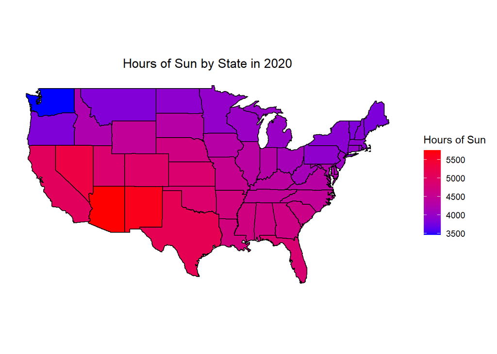

Out of the 48 contiguous states, Utah leads the way in happiness score. This score was formed using overall physical and mental well-being, as well as work and community environment. Minnesota follows closely behind, along with New Jersey and both of the Dakotas. West Virginia and Mississippi have the lowest scores, with many of the surrounding area recording low scores as well.

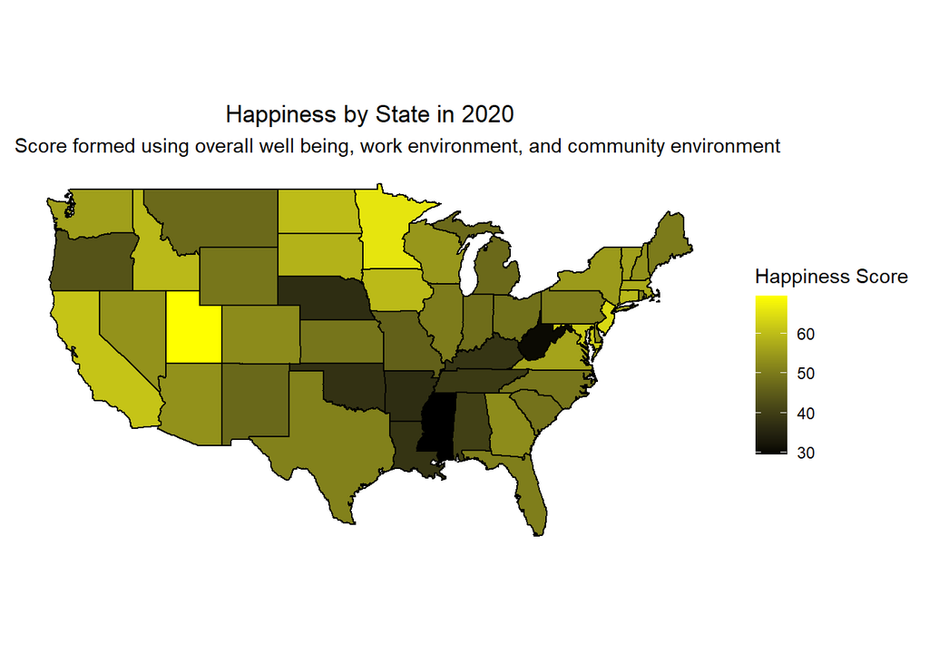

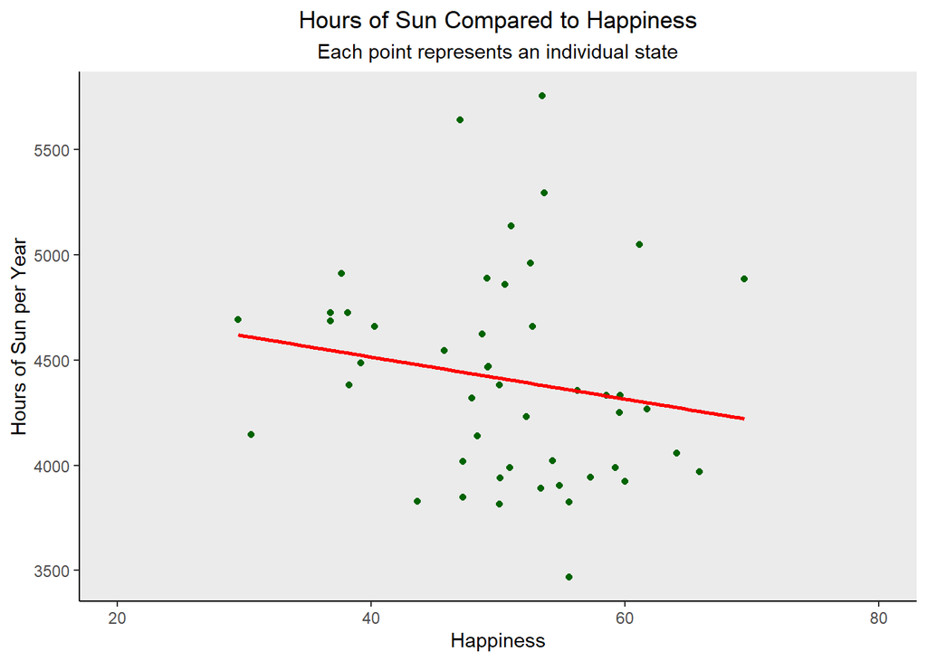